# Good plot Bad plot

Roshan

2023-03-19

### Loading libraries

```r
library(here)
library(tidyverse)
library(ggmap)
library(ggsn)
```

```r
library(ggplot2)
library(lubridate)
library(dplyr)
library(data.table)
library(ggtext)
library(gapminder)
library(ggimage)
library(png)
library(patchwork)
```

### Read in crime data

```r
LAcrimedata <- read_csv(here("Goodplot_Badplot","Data", "Crime_Data_from_2020_to_Present.csv"))
##view(LAcrimedata) LA has committed enough crime that the dataset will burn out your cpu
```

### Filtering & cleaning data

```r
LAcrimedata <- LAcrimedata %>%
  select("DATE OCC", "AREA NAME", "Crm Cd Desc", "LAT", "LON")

filterLA <- LAcrimedata %>% rename(date_occ = `DATE OCC`)

filterLA <- filterLA %>%
  mutate(crime_year = year(mdy_hm(date_occ)))

filterLA <- filterLA %>%
  select( -date_occ)

filterLA <- filterLA %>%
  filter(crime_year != 2023)

filterLA <- filterLA %>%
  filter(`Crm Cd Desc` == "CRIMINAL HOMICIDE")
```

### Create base map

```r
LA<-get_map("Los Angeles", zoom = 10)
```

### Creating **BAD** plot

[output not shown]

[figure not shown]

```r
ggmap(LA)+
    geom_point(data = filterLA,
              aes(x = LON, y = LAT), color = "magenta", size = 4, alpha = 0.6)+
            coord_cartesian(xlim = c(-118.7, -118.1), ylim = c(33.7, 34.35))+
      facet_wrap(~crime_year)+
      labs(title = "A frequency comparison of LA's yearly reported homicides")+
      theme(plot.title = element_text(color = "orange", size = 18))
```

```r
#ggsave(here("Week_09", "Output", "bad_plot.png"))
```

### List of bad plot offences

- This data has been used to produce a plot that is intended to show a rise or fall in the frequency of murders for each year since 2020. Homicide frequency can not be visually quantified by the map plot used for this data.
- The pink color is not suitable and somewhat trivial for a map of points consisting of homicide data.
- The point sizes are too large covering many area names and other points.
- The transparency of the points need to be increased as the points are too dark to distinguish between one another. at half the setting around an alpha of 0.3, there would be far more visible data points, albeit still far from a clear year on year frequency comparison of homicides in the LA region
- Using scale_x_discrete to exclude the outer most 2 longitude values which would have prevented the x axis value overlaps between each map facet.
- Color of plot title is inconsistent with the rest of the plot and subject.

### **GOOD** plot read in data

```r
LAcrimedata <- read_csv(here("Goodplot_Badplot","Data", "Crime_Data_from_2020_to_Present.csv"))
```

### Filtering & cleaning data

```r
LAcrimedata <- LAcrimedata %>%
  select("DATE OCC", "AREA NAME", "Crm Cd Desc", "LAT", "LON")

filterLA <- LAcrimedata %>% rename(date_occ = `DATE OCC`)

filterLA <- filterLA %>%
  mutate(crime_year = year(mdy_hm(date_occ)))

filterLA <- filterLA %>%
  select( -date_occ)

filterLA <- filterLA %>%
  filter(crime_year != 2023)

filterLA <- filterLA %>%
  filter(`Crm Cd Desc` == "CRIMINAL HOMICIDE")

filterLA <- filterLA %>% mutate(row_count = row_number())

#view(filterLA)
```

### Creating **Good** plot

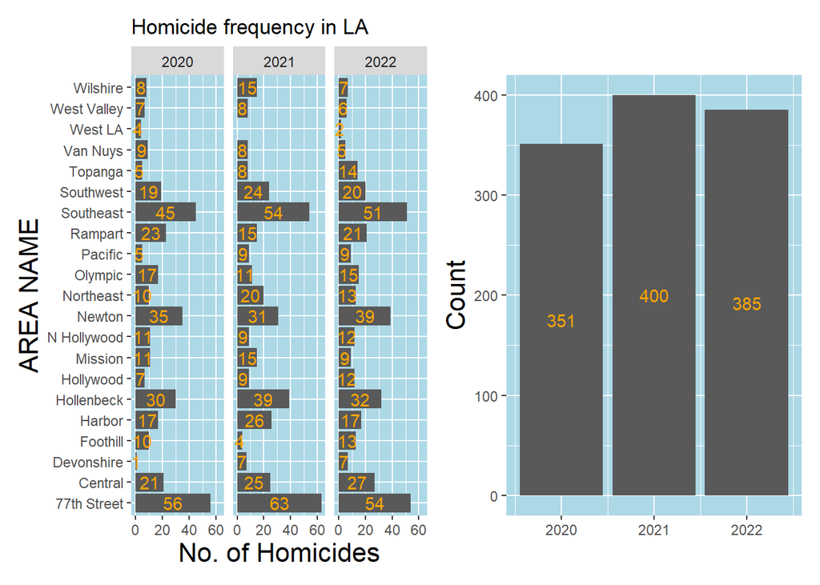

```r
p1 <- ggplot(data = filterLA, aes(y = `AREA NAME`))+
      geom_bar()+
facet_wrap(~crime_year)+

  geom_text(stat = "count", aes(label = ..count..),color = "orange", position = position_stack(vjust = 0.5))+

  labs(title = "Homicide frequency in LA")+
       theme(plot.title = element_text(color = "orange"))+
theme_gray()+
  theme(panel.background = element_rect(fill = "light blue"))+
  labs(x = "No. of Homicides")+
  theme(axis.title = element_text(size = 16, color = "black"))


p2 <- ggplot(data = filterLA, aes(x = crime_year))+
  geom_bar()+
  geom_text(stat = "count", aes(label = ..count..),color = "orange", position = position_stack(vjust = 0.5))+
  theme_gray()+
  theme(panel.background = element_rect(fill = "light blue"))+
  labs(x = NULL, y = "Count")+
  theme(axis.title = element_text(size = 16, color = "black"))
p1+p2
```

```r
#ggsave(here("Goodplot_Badplot", "Output", "good_plot.png"))
```

### **GOOD** plot improvements

- clear visual interpretation of homicide counts for year
- Individual area homicide counts can now be clearly seen
- Accurate comparison of homicide occurrences between all the areas.
- All axis values are clear and not overlapping
- All the wording and data points are on the y axis which is much easier to read than if they were displayed vertically on the x axis.
- The colors orange on dark grey bars and light blue background seems to work well enough without resorting to using boring colors given the nature of the assignment.